# Trending Videos (Data Story)

The First step in for any project is to install and load the necessary packages by declaring the libraries. The plyr package is to be used to select the variables in the clean data and the tidy verse for most of the other functions. Tidyverse is considered the swiss knife because of its unlimited capabilities. All packages used in the data wrangling process and the statistics are loaded into the console.

```r
library(tidyverse) #The swiss knife!
```

```r
library(ggplot2)
library(rmarkdown)
library(dplyr)
library(tidyr)
```

To begin the cleaning process, we take a peek at the working directory with the getwd() function. If the working directory is not set to read the files, then the working directory has to be changed. The working directory is confirmed, and the data is imported.

```r
getwd()
```

```
## [1] "D:/Lopez"
```

```r
df <- read.csv("YouTube.csv")
```

```r
str(df)
```

```
## 'data.frame':    40881 obs. of  14 variables:
##  $ video_id              : Factor w/ 24104 levels "--45ws7CEN0",..: 14219 586 2731 6677 1594 847 387 1465 11920 2086 ...
##  $ trending_date         : Factor w/ 205 levels "17.01.12","17.02.12",..: 14 14 14 14 14 14 14 14 14 14 ...
##  $ title                 : Factor w/ 24573 levels "''Gala Artis 2018'' Le numÃ©ro d'ouverture",..: 7886 16653 17304 10553 7746 11410 22920 23362 20575 8523 ...
##  $ channel_title         : Factor w/ 5076 levels "- æ¬¢è¿Žè®¢é\230… -æµ\231æ±Ÿå\215«è§†ã\200\220å¥”è·‘å\220§ã\200‘å®\230æ–¹é¢‘é\201“",..: 1430 2067 3755 3216 1391 1304 4767 810 2675 3905 ...
##  $ category_id           : int  10 23 23 24 10 25 23 22 24 22 ...
##  $ publish_time          : Factor w/ 23613 levels "2008-01-13T01:32:16.000Z",..: 68 260 180 172 55 228 205 265 188 64 ...
##  $ tags                  : Factor w/ 20157 levels "''Hace|\"minuto''\"|\"''hace\"|\"minutos''\"|\"''MÃ¡quinas''\"|\"''animales''\"|\"''mejores''\"|\"tops''\"|\"''"| __truncated__,..: 5897 13838 14461 15239 5761 19 6961 15782 11002 7337 ...
##  $ views                 : int  17158579 1014651 3191434 2095828 33523622 1309699 2987945 748374 4477587 505161 ...
##  $ likes                 : int  787425 127794 146035 132239 1634130 103755 187464 57534 292837 4135 ...
##  $ dislikes              : int  43420 1688 5339 1989 21082 4613 9850 2967 4123 976 ...
##  $ comment_count         : int  125882 13030 8181 17518 85067 12143 26629 15959 36391 1484 ...
##  $ comments_disabled     : logi  FALSE FALSE FALSE FALSE FALSE FALSE ...
##  $ ratings_disabled      : logi  FALSE FALSE FALSE FALSE FALSE FALSE ...
##  $ video_error_or_removed: logi  FALSE FALSE FALSE FALSE FALSE FALSE ...
```

The view function gives a table of all observations and variables. Some of the variables were easier to understand than others. The varialbes such as likes, dislikes, comment count, and views were plainly understood. The other variables did not have units specified, which makes it hard to interpret. There are missing variables in the data set labeled as NA. Let’s take a glimpse of the data set.

The glimpse function provides more concise information regarding the data set. A glimpse of the data set is called to determine the type of variables and ensure that the data set is correct.

```r
glimpse(df)
```

```
## Observations: 40,881
## Variables: 14
## $ video_id               <fct> n1WpP7iowLc, 0dBIkQ4Mz1M, 5qpjK5DgCt4, ...
## $ trending_date          <fct> 17.14.11, 17.14.11, 17.14.11, 17.14.11,...
## $ title                  <fct> "Eminem - Walk On Water (Audio) ft. Bey...
## $ channel_title          <fct> EminemVEVO, iDubbbzTV, Rudy Mancuso, ni...
## $ category_id            <int> 10, 23, 23, 24, 10, 25, 23, 22, 24, 22,...
## $ publish_time           <fct> 2017-11-10T17:00:03.000Z, 2017-11-13T17...
## $ tags                   <fct> Eminem|"Walk"|"On"|"Water"|"Aftermath/S...
## $ views                  <int> 17158579, 1014651, 3191434, 2095828, 33...
## $ likes                  <int> 787425, 127794, 146035, 132239, 1634130...
## $ dislikes               <int> 43420, 1688, 5339, 1989, 21082, 4613, 9...
## $ comment_count          <int> 125882, 13030, 8181, 17518, 85067, 1214...
## $ comments_disabled      <lgl> FALSE, FALSE, FALSE, FALSE, FALSE, FALS...
## $ ratings_disabled       <lgl> FALSE, FALSE, FALSE, FALSE, FALSE, FALS...
## $ video_error_or_removed <lgl> FALSE, FALSE, FALSE, FALSE, FALSE, FALS...
```

The table shows that there is 14 variables and 40,881 observations. The variables are labelled as factor,integer, and lgl.

## Data Wrangling

Data wrangling is one of the most essential parts of a data science project. Data wrangling is the process of mapping data from raw to a format appropriate for the data to be analyzed. Data wrangling consists of selecting, indexing, and mutating the tables to form them for your need. This process helps with better decision making, but it takes a long time to complete. If it is done correctly, then a data scientist life is made easier. These steps will help to deliver more accurate results. The data used contained 14 variables and 40,881 observations. They are multiple techniques used to clean and conform the data before the analysis. The packages have been loaded in a previous code chunk. The loaded packages allow syntax that is simple to use when cleaning the data. The first step is to remove unnecessary variables which are the columns of the data set. Once the columns are removed, the data set is reviewed using the glimpse function.

```r
df <- df[c(-1,-4,-5,-6,-7,-12,-13,-14,-15,-16)]
glimpse(df)
```

```
## Observations: 40,881
## Variables: 6
## $ trending_date <fct> 17.14.11, 17.14.11, 17.14.11, 17.14.11, 17.14.11...
## $ title         <fct> "Eminem - Walk On Water (Audio) ft. BeyoncÃ©", "...
## $ views         <int> 17158579, 1014651, 3191434, 2095828, 33523622, 1...
## $ likes         <int> 787425, 127794, 146035, 132239, 1634130, 103755,...
## $ dislikes      <int> 43420, 1688, 5339, 1989, 21082, 4613, 9850, 2967...
## $ comment_count <int> 125882, 13030, 8181, 17518, 85067, 12143, 26629,...
```

```r
nrow(df)
```

```
## [1] 40881
```

The table shows that there is 6 variables and 40,881 observations. The variables are labelled as factor and integer. By removing insignificant variables from the data frame, the new data set contains the variables trending date, title likes, view, dislikes, and comment count. Theses variable provides information pertinent information regarding the trending videos.

```r
df[df == 0] <- NA
df <- na.omit(df)
glimpse(df)
```

```
## Observations: 39,924
## Variables: 6
## $ trending_date <fct> 17.14.11, 17.14.11, 17.14.11, 17.14.11, 17.14.11...
## $ title         <fct> "Eminem - Walk On Water (Audio) ft. BeyoncÃ©", "...
## $ views         <int> 17158579, 1014651, 3191434, 2095828, 33523622, 1...
## $ likes         <int> 787425, 127794, 146035, 132239, 1634130, 103755,...
## $ dislikes      <int> 43420, 1688, 5339, 1989, 21082, 4613, 9850, 2967...
## $ comment_count <int> 125882, 13030, 8181, 17518, 85067, 12143, 26629,...
```

Since the missing data values have been deleted the number of observations are minimized. The table shows that there is 6 variables and 39,924 observations. The variables are labelled as factor and integer. The data is numerical. Thus we look at a summary of the data.

```r
mean(df$views)
```

```
## [1] 1153527
```

```r
summary(df$views)
```

```
##      Min.   1st Qu.    Median      Mean   3rd Qu.      Max.
##      1023    148818    377166   1153527    970374 137843120
```

```r
df_1<-df %>% filter(views>=148818)
glimpse(df_1)
```

```
## Observations: 29,943
## Variables: 6
## $ trending_date <fct> 17.14.11, 17.14.11, 17.14.11, 17.14.11, 17.14.11...
## $ title         <fct> "Eminem - Walk On Water (Audio) ft. BeyoncÃ©", "...
## $ views         <int> 17158579, 1014651, 3191434, 2095828, 33523622, 1...
## $ likes         <int> 787425, 127794, 146035, 132239, 1634130, 103755,...
## $ dislikes      <int> 43420, 1688, 5339, 1989, 21082, 4613, 9850, 2967...
## $ comment_count <int> 125882, 13030, 8181, 17518, 85067, 12143, 26629,...
```

The table shows that the data set df_1 has 6 variables and 29,943 observations. Let’s take a look at the summary of df_1 to view the changes in the mean number of views.

```r
summary(df_1$views)
```

```
##      Min.   1st Qu.    Median      Mean   3rd Qu.      Max.
##    148823    304129    586076   1512629   1325222 137843120
```

There is evidence that some trending videos are more popular than others. A popularity index is created to distinguish between highly trending and trending videos based on the number of views. The threshold is selected to be 586,076 the medeian number of views.

```r
df_1$Popularity_Index <- ifelse(( df_1$views >= 586076), '1', '0')
```

We take one last look at the clean data set and write it to the console.

```r
glimpse(df_1)
```

```
## Observations: 29,943
## Variables: 7
## $ trending_date    <fct> 17.14.11, 17.14.11, 17.14.11, 17.14.11, 17.14...
## $ title            <fct> "Eminem - Walk On Water (Audio) ft. BeyoncÃ©"...
## $ views            <int> 17158579, 1014651, 3191434, 2095828, 33523622...
## $ likes            <int> 787425, 127794, 146035, 132239, 1634130, 1037...
## $ dislikes         <int> 43420, 1688, 5339, 1989, 21082, 4613, 9850, 2...
## $ comment_count    <int> 125882, 13030, 8181, 17518, 85067, 12143, 266...
## $ Popularity_Index <chr> "1", "1", "1", "1", "1", "1", "1", "1", "1", ...
```

```r
write.csv(df_1, file = "df_1clean.csv")
```

The clean data set has 7 variables and 29,943 observations. The clean data set is called df_1clean.

## Statistics

Now that the data set is cleaned, it is time for the statistical analysis. This analysis is the exploratory portion of the project. At this time, we are trying to find trends in the project data based on the facts and develop a solid hypothesis. In this portion of the coding in R, plots are created and analyzed. A deep analysis of the trending videos is investigated. Teh following code confirms that the correct data set is used.

```r
df_1clean <- read.csv("df_1clean.csv")
df_1clean <- select(df_1clean, -c(X))
glimpse(df_1clean)
```

```
## Observations: 29,943
## Variables: 7
## $ trending_date    <fct> 17.14.11, 17.14.11, 17.14.11, 17.14.11, 17.14...
## $ title            <fct> "Eminem - Walk On Water (Audio) ft. BeyoncÃ©"...
## $ views            <int> 17158579, 1014651, 3191434, 2095828, 33523622...
## $ likes            <int> 787425, 127794, 146035, 132239, 1634130, 1037...
## $ dislikes         <int> 43420, 1688, 5339, 1989, 21082, 4613, 9850, 2...
## $ comment_count    <int> 125882, 13030, 8181, 17518, 85067, 12143, 266...
## $ Popularity_Index <int> 1, 1, 1, 1, 1, 1, 1, 1, 1, 0, 1, 1, 0, 1, 1, ...
```

The table shows that there is 7 variables and 29,943 observations. The variables are labelled as factor and integer.

Since there is an enormous amount of data for trending videos, the means of each variable is explored. The code to find the means is written below.

```r
daily_means <- df_1clean  %>%
  group_by(trending_date) %>%
  summarise(n_title = n(),
            mean_likes = mean(likes),
             mean_views = mean(views),
             mean_dislikes = mean(dislikes),
            mean_comment_count = mean(comment_count))
daily_means
```

```
## # A tibble: 205 x 6
##    trending_date n_title mean_likes mean_views mean_dislikes
##    <fct>           <int>      <dbl>      <dbl>         <dbl>
##  1 17.01.12          162     48910.   1348747.         2586.
##  2 17.02.12          143     70996.   1671943.         2457.
##  3 17.03.12          148     78798.   1981795.         2893.
##  4 17.04.12          159     76604.   2158642.         3239.
##  5 17.05.12          145     83257.   2371184.         3312.
##  6 17.06.12          133     72899.   2114607.         2204.
##  7 17.07.12          150     70974.   2230864.         5387.
##  8 17.08.12          143     49521.   1624565.         8152.
##  9 17.09.12          158     61073.   1962479.         9472.
## 10 17.10.12          156     63623.   1932300.        10399.
## # ... with 195 more rows, and 1 more variable: mean_comment_count <dbl>
```

The mean for the variables, likes, dislikes, views, and comment_count is collect for each trending date. The table also shows the number of videos per date. A graphical analysis of the means is annotated in the code below. We conduct this anlysis as it reduces the number of data points and patterns can be seen.

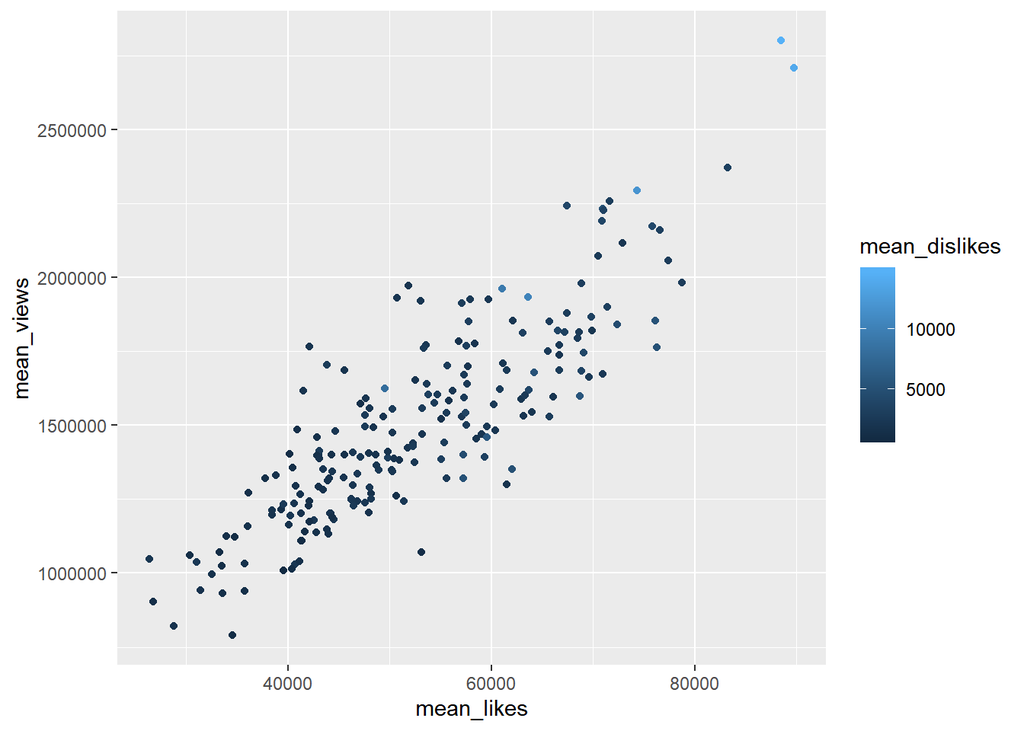

```r
ggplot(daily_means, aes(y = mean_views, x = mean_likes, color=mean_dislikes)) + geom_point() + geom_jitter()
```

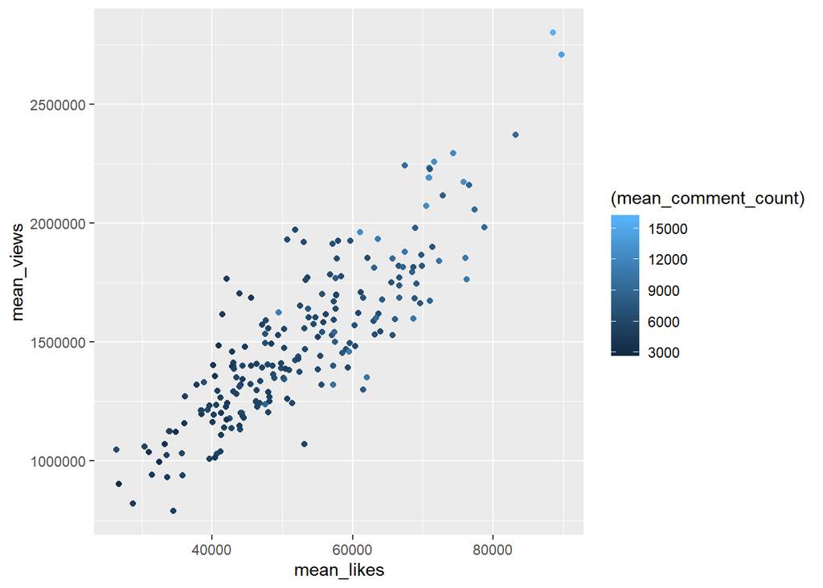

```r
ggplot(daily_means, aes(y = mean_views, x = mean_likes, color=(mean_comment_count))) + geom_point() + geom_jitter()
```

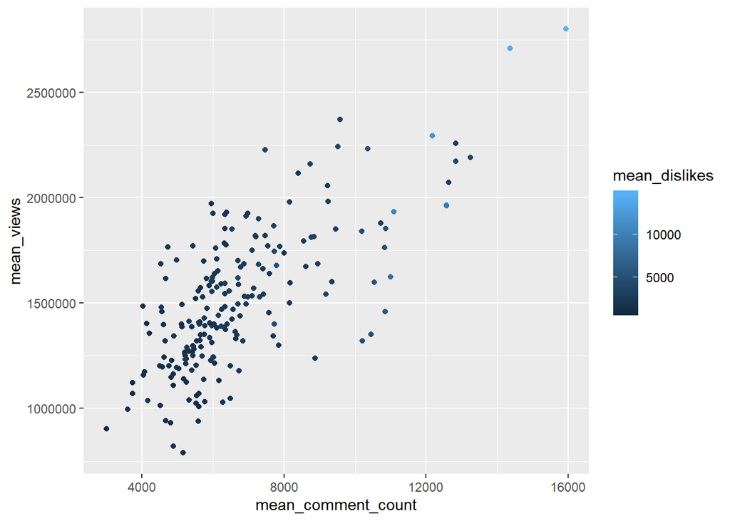

```r
ggplot(daily_means, aes(y = mean_views, x = mean_comment_count,  color=mean_dislikes)) + geom_point() + geom_jitter()
```

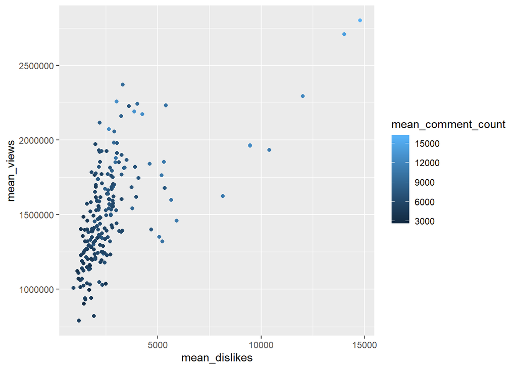

```r
ggplot(daily_means, aes(y = mean_views, x = mean_dislikes,color=mean_comment_count)) + geom_point() + geom_jitter()
```

The plots show strong positive relationships between the means of the independent and dependent variables. Thus there may be a strong correlation between the actual variables. Note that a trending video that has an extremely large number of likes and views it also has a vast amount of dislikes and comments.

[figure not shown]

```r
bp <- ggplot(df_1clean, aes(x=Popularity_Index, y=likes, fill=Popularity_Index)) +
  geom_boxplot()+
  labs(title="Plot of Views Given Likes",x="Popularity Index", y = "Number of Views")+
scale_x_discrete(limits=c("Popular", "Highly Popular"))
bp + theme_classic()
```

There are too many outliers to use a box plot :( . I leave it to show the complete anlysis that was conducted.

Let’s take a look at the Popularity_Index variable that was created.

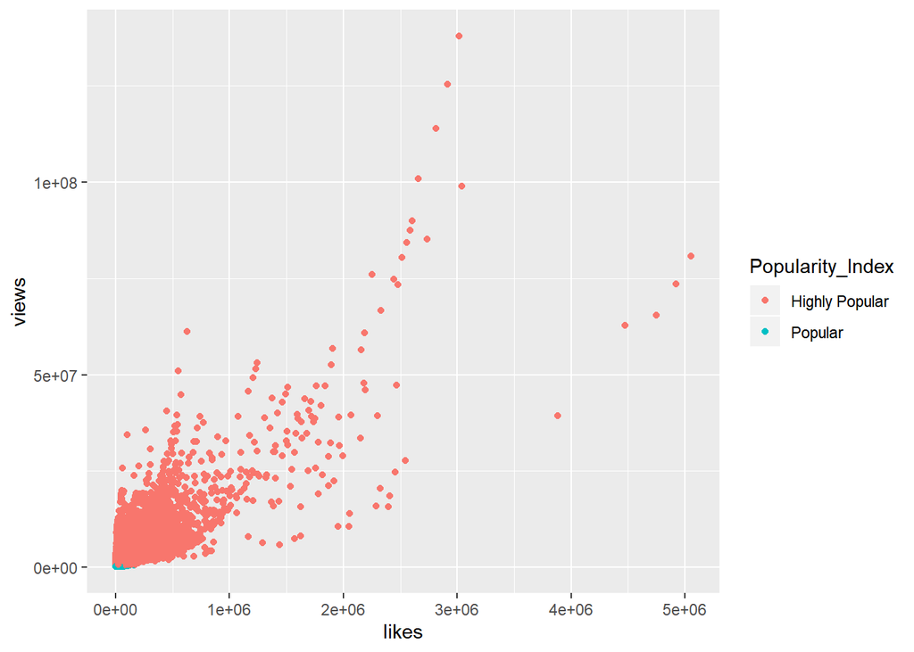

```r
df_1clean$Popularity_Index <- ifelse(df_1clean$Popularity_Index == 1, 'Highly Popular', 'Popular')
ggplot(df_1clean, aes(x = likes, y = views, color=Popularity_Index)) +
  geom_point() + geom_jitter()
```

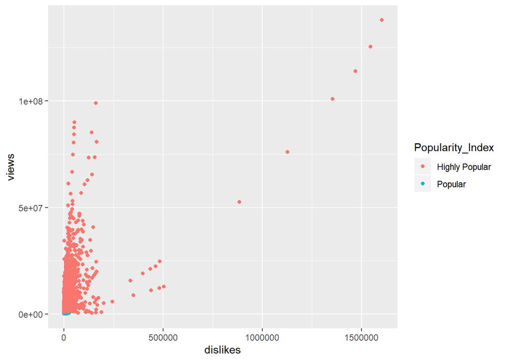

```r
ggplot(df_1clean, aes(x = dislikes, y = views, color=Popularity_Index)) +
  geom_point() + geom_jitter()
```

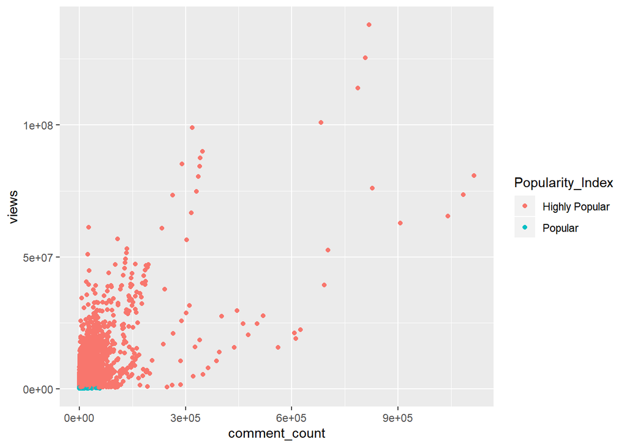

```r
ggplot(df_1clean, aes(x = comment_count, y = views, color=Popularity_Index)) +
  geom_point() + geom_jitter()
```

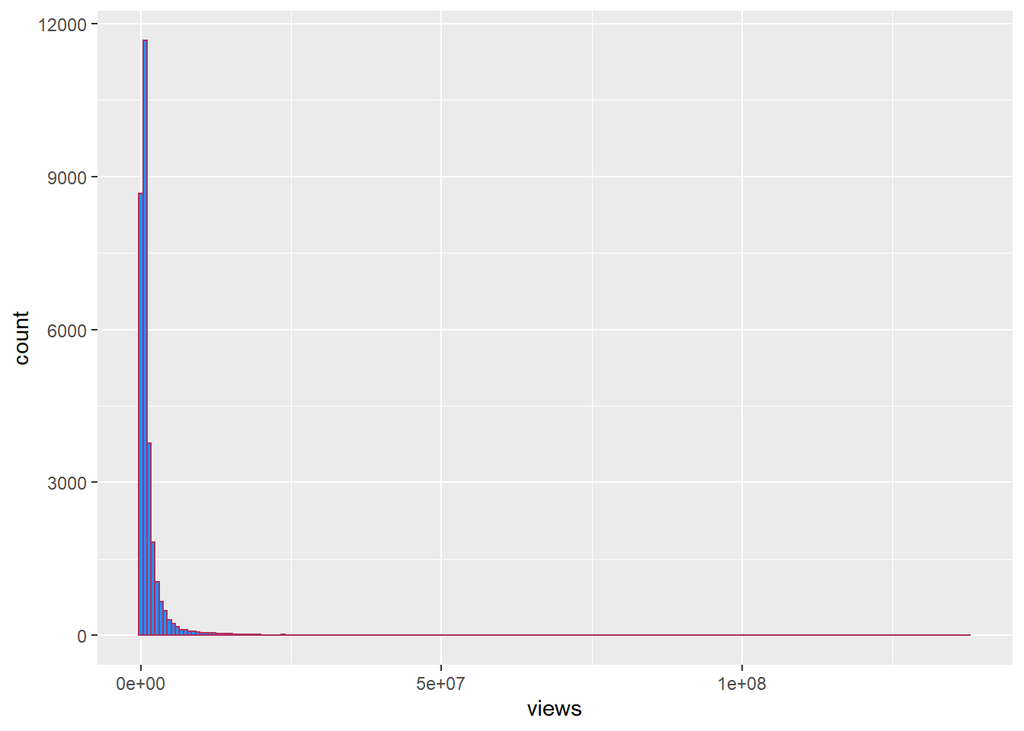

```r
 hist_plot <-
   df_1clean %>%
     ggplot(aes(x = views)) +
     geom_histogram(color = "maroon", fill = "dodgerblue", bins = 205)
  print(hist_plot)
```

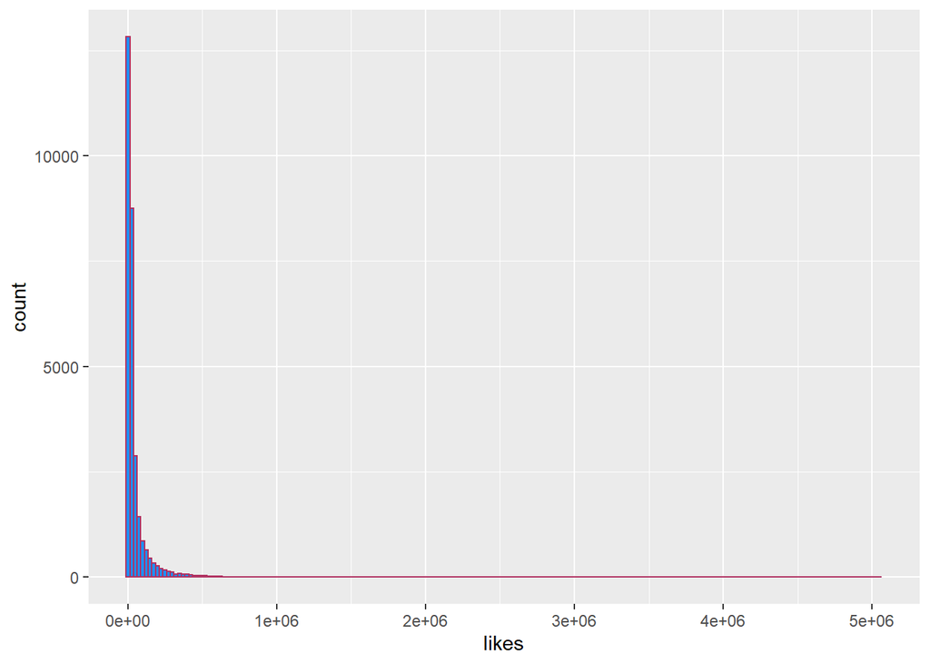

```r
  hist_plot <-
   df_1clean %>%
     ggplot(aes(x = likes)) +
     geom_histogram(color = "maroon", fill = "dodgerblue", bins = 205)
  print(hist_plot)
```

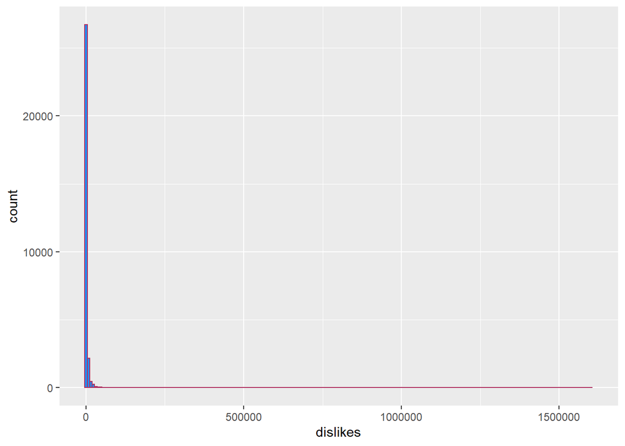

```r
  hist_plot <-
   df_1clean %>%
     ggplot(aes(x = dislikes)) +
     geom_histogram(color = "maroon", fill = "dodgerblue", bins = 205)
  print(hist_plot)
```

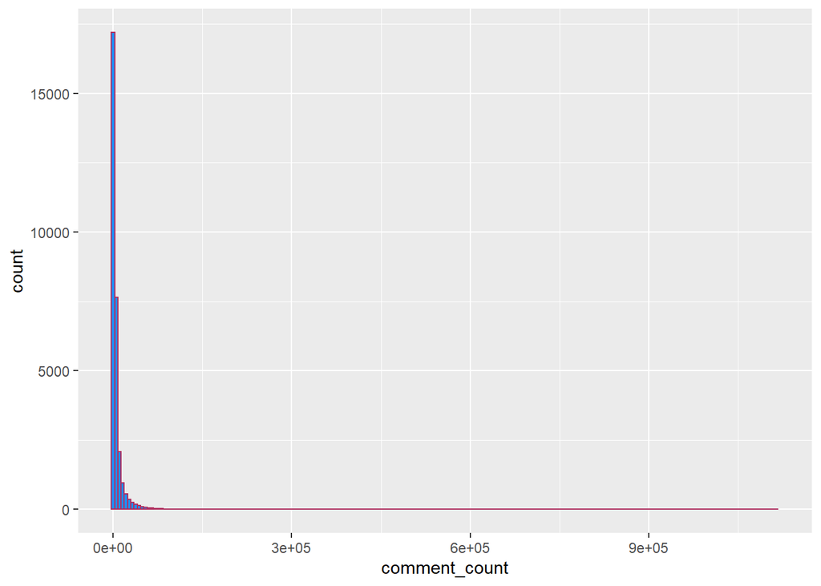

```r
  hist_plot <-
   df_1clean %>%
     ggplot(aes(x = comment_count)) +
     geom_histogram(color = "maroon", fill = "dodgerblue", bins = 205)
  print(hist_plot)
```

```r
write.csv(daily_means, file = "daily_means.csv")
```